# Simple Neural Networks Exercises

Hicham Zmarrou

2018-12-06

#### Exercise 1

We’ll start by creating the data set on which we want to do a simple regression. Set the seed to 42, generate 200 random points between -10 and 10 and store them in a vector named X. Then, create a vector named Y containing the value of sin(x). Neural network are a lot more flexible than most regression algorithms and can fit complex function with ease. The biggest challenge is to find the appropriate network function appropriate to the situation.

#### Exercise 2

A network function is made of three components: the network of neurons, the weight of each connection between neuron and the activation function of each neuron. For this example, we’ll use a feed-forward neural network and the logistic activation which are the defaults for the package `nnet`. We take one number as input of our neural network and we want one number as the output so the size of the input and output layer are both of one. For the hidden layer, we’ll start with three neurons. It’s good practice to randomize the initial weights, so create a vector of 10 random values, picked in the interval [-1,1].

#### Exercise 3

Neural networks have a strong tendency of overfitting your data, meaning they become really good at describing the relationship between the values in your data set, but are not effective with data that wasn’t used to train your model. As a consequence, we need to cross-validate our model. Set the seed to 42, then create a training set containing 75% of the values in your initial data set and a test set containing the rest of your data.

#### Exercise 4

Load the `nnet` package and use the function of the same name to create your model. Pass your weights via the Wts argument and set the maxit argument to 50. We want to fit a function which can have for output multiple possible values. To do so, set the linout argument to true. Finally, take the time to look at the structure of your model.

#### Exercise 5

Predict the output for the test set and compute the `RMSE`c of your predictions. Plot the function sin(x) and then plot your predictions.

#### Exercise 6

The number of neurons in the hidden layer, as well as the number of hidden layer used, has a great influence on the effectiveness of your model. Repeat the exercises three to five, but this time use a hidden layer with seven neurons and initiate randomly 22 weights.

#### Exercise 7

Now let us use neural networks to solve a classification problem, so let’s load the iris data set! It is good practice to normalize your input data to uniformize the behavior of your model over different range of value and have a faster training. Normalize each factor so that they have a mean of zero and a standard deviation of 1, then create your train and test set.

#### Exercise 9

Make prediction with the values of the test set.

#### Exercise 10

Create the confusion table of your prediction and compute the accuracy of the model.

#### Solution 1

```r
set.seed(42)
x<-runif(200, -10, 10)
y<-sin(x)
```

#### Solution 2

```r
weight <-runif(10, -1, 1)
```

#### Solution 3

```r
set.seed(42)
index<-sample(1:length(x),round(0.75*length(x)),replace=FALSE)
reg.train<-data.frame(X=x[index],Y=y[index])
reg.test<-data.frame(X=x[-index],Y=y[-index])
```

#### Solution 4

```r
library(nnet)
set.seed(42)
reg.model.1<-nnet(reg.train$X,reg.train$Y,size=3,maxit=50,Wts=weight,linout=TRUE)
str(reg.model.1)
```

```
## List of 15
##  $ n            : num [1:3] 1 3 1
##  $ nunits       : int 6
##  $ nconn        : num [1:7] 0 0 0 2 4 6 10
##  $ conn         : num [1:10] 0 1 0 1 0 1 0 2 3 4
##  $ nsunits      : num 5
##  $ decay        : num 0
##  $ entropy      : logi FALSE
##  $ softmax      : logi FALSE
##  $ censored     : logi FALSE
##  $ value        : num 39.9
##  $ wts          : num [1:10] -7.503 2.202 3.004 -0.806 -4.69 ...
##  $ convergence  : int 1
##  $ fitted.values: num [1:150, 1] -0.196 0.568 -0.353 -0.205 -0.161 ...
##   ..- attr(*, "dimnames")=List of 2
##   .. ..$ : NULL
##   .. ..$ : NULL
##  $ residuals    : num [1:150, 1] 0.692 0.3079 -0.0398 0.4262 -0.7024 ...
##   ..- attr(*, "dimnames")=List of 2
##   .. ..$ : NULL
##   .. ..$ : NULL
##  $ call         : language nnet.default(x = reg.train$X, y = reg.train$Y, size = 3, Wts = weight,      linout = TRUE, maxit = 50)
##  - attr(*, "class")= chr "nnet"
```

#### Solution 5

```r
predict.model.1<-predict(reg.model.1,data.frame(X=reg.test$X))
str(predict.model.1)
```

```
##  num [1:50, 1] -0.201 0.184 -0.873 -0.981 0.598 ...
##  - attr(*, "dimnames")=List of 2
##   ..$ : NULL
##   ..$ : NULL
```

```r
rmse.reg<-sqrt(sum((reg.test$Y-predict.model.1)^2))
rmse.reg
```

```
## [1] 3.41651
```

plot the sin and the prediction

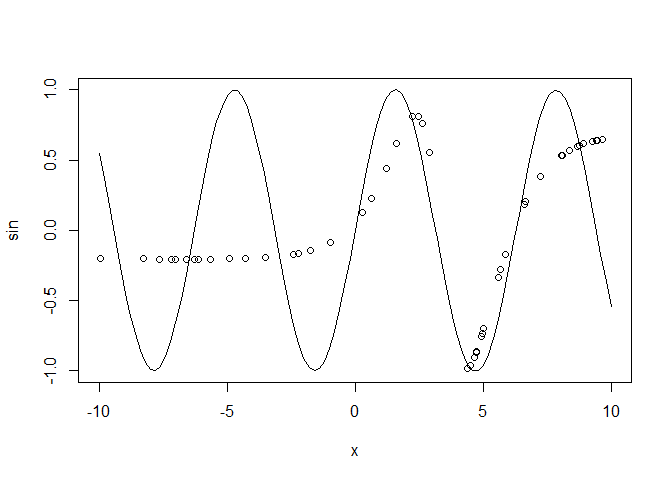

```r
plot(sin, -10, 10)
points(reg.test$X,predict.model.1)
```

#### Solution 6

```r
set.seed(42)
reg.model.2<-nnet(reg.train$X,reg.train$Y,size=7,maxit=50,Wts=runif(22, -1, 1),linout=TRUE)
str(reg.model.2)
```

```
## List of 15
##  $ n            : num [1:3] 1 7 1
##  $ nunits       : int 10
##  $ nconn        : num [1:11] 0 0 0 2 4 6 8 10 12 14 ...
##  $ conn         : num [1:22] 0 1 0 1 0 1 0 1 0 1 ...
##  $ nsunits      : num 9
##  $ decay        : num 0
##  $ entropy      : logi FALSE
##  $ softmax      : logi FALSE
##  $ censored     : logi FALSE
##  $ value        : num 12.8
##  $ wts          : num [1:22] 0.894 0.992 1.997 1.506 8.113 ...
##  $ convergence  : int 1
##  $ fitted.values: num [1:150, 1] 0.585 0.6145 -0.464 0.0943 -0.8862 ...
##   ..- attr(*, "dimnames")=List of 2
##   .. ..$ : NULL
##   .. ..$ : NULL
##  $ residuals    : num [1:150, 1] -0.0891 0.2612 0.071 0.1269 0.0232 ...
##   ..- attr(*, "dimnames")=List of 2
##   .. ..$ : NULL
##   .. ..$ : NULL
##  $ call         : language nnet.default(x = reg.train$X, y = reg.train$Y, size = 7, Wts = runif(22,      -1, 1), linout = TRUE, maxit = 50)
##  - attr(*, "class")= chr "nnet"
```

```r
predict.model.2<-predict(reg.model.2,data.frame(X=reg.test$X))
str(predict.model.2)
```

```
##  num [1:50, 1] 1.13 0.153 -0.931 -0.962 0.647 ...
##  - attr(*, "dimnames")=List of 2
##   ..$ : NULL
##   ..$ : NULL
```

```r
rmse.reg<-sqrt(sum((reg.test$Y-predict.model.2)^2))
rmse.reg
```

```
## [1] 2.188407
```

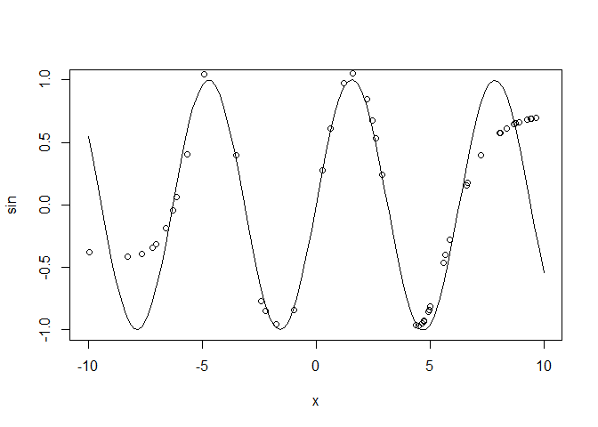

```r
## [1] 2.188407
plot(sin, -10, 10)
points(reg.test$X,predict.model.2)
```

#### Solution 7

```r
data<-iris

scale.data<-data.frame(lapply(data[,1:4], function(x) scale(x)))
scale.data$Species<-data$Species

index<-sample(1:nrow(scale.data),round(0.75*nrow(scale.data)),replace=FALSE)
clust.train<-scale.data[index,]
clust.test<-scale.data[-index,]
```

#### Solution 8

```r
set.seed(42)
clust.model<-nnet(Species~.,size=10,Wts=runif(83, -1, 1),data=clust.train)
```

#### Solution 9

```r
predict.model.clust<-predict(clust.model,clust.test[,1:4],type="class")
```

#### Solution 10

```r
Table<-table(clust.test$Species ,predict.model.clust)
Table
```

```
##             predict.model.clust
##              setosa versicolor virginica
##   setosa         16          0         0
##   versicolor      0          9         0
##   virginica       0          0        13
```

```r
accuracy<-sum(diag(Table))/sum(Table)
accuracy
```

```
## [1] 1
```